# Bellabeat Wellness Company Case Study with R

Maria Williams

4/3/2022

# Bellabeat Wellness Company Case Study with R

### Table of Contents

1. Summary
2. Introduction
3. Data Preparation
4. Data Exploration
5. Analyze and Visualize
6. Discussion
7. Recommendations

## 1. Summary

The health-focused global smart device market has been booming for over eight years, and the market projection is to reach almost 25 billion by 2025. The smart devices categories include diagnostics, monitoring, and therapeutic, and some of the key players in the market are Fitbit and Apple. Fitbit has contributed to the accelerated growth of smart devices through partnerships which includes their health screening and monitoring app, FibriCheck. For instance, users in European countries like Germany and France can monitor their heart rhythm for abnormalities with their Fitbit smart watch. In addition, Amazon has recently joined the race by launching a fitness tracker that can track fat mass and even the person’s emotions.

The case study utilizes data from Fitbit to analyze the Bellabeat app, which allows users to track health data in terms of fitness, sleep, menstrual cycle, and mindfulness habits. Analyzing Fitbit users’ data will provide insights on the usage of smart tracking devices. These questions will guide the analysis:

1. What are some trends in smart device usage?
2. How could these trends apply to Bellabeat customers?
3. How could these trends help influence Bellabeat marketing strategy?

**Approach:**

An **exploratory approach** will guide the analysis with a series of questions, trends, and regression analyses. The idea is to explore users’ habits based on their tracker. Thirty eligible Fitbit users provided their consent to use their data. Their answers will aid in exploring their activity tracking in the app.

Fitness trackers such as Bellabeat or Fitbit provide information into users’ routines and device usage, which can illuminate marketing campaign objectives. Therefore, the purpose of the below questions is to take a deeper dive into the analysis:

1. Which features of the app can help users track their activity?
2. How are users tracking their weight in the app and connected devices such as scales?

Daily data tracked for physical activity, and weight measurements levels are part of the analysis.

**Disclaimer:** All the data is research-based only.

## 2. Introduction

**Bellabeat Wellness Coach App**

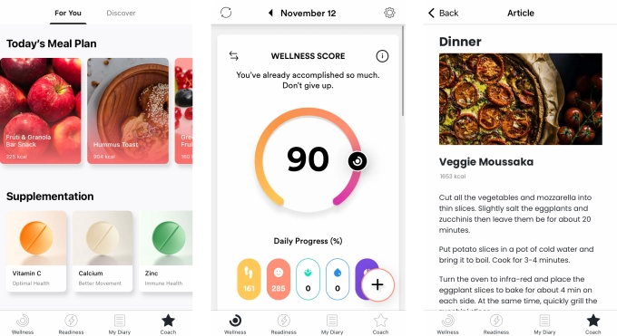

**App Description:**

Bellabeat app is a repository for all Bellabeat devices and products such as:

- Leaf
- Wellness tracker
- Spring
- Smart water bottle
- Time, a hybrid wellness watch

The app ” is **a combination of a holistic wellness coach and tracker designed for women**.” - Bellabeat.

### App Features:

- Personalized coaching programs
- App releases monthly enhanced programs
- App reads and transforms information such as sleep and activity tracking and breathing exercises captured by Bellabeat devices. The processed information becomes usable fitness and wellness data
- App motivational notifications feature encourages users

**Fitbit App**

[figure not shown]

## App Description:

The Fitbit app is a customizable software that allows users to understand their statistical data and fitness progress better. The app provides insightful information for the user to reach fitness goals and objectives, “**Meet the app that puts a world of health & fitness in your hands**. -fitbit.com

## App Features:

- Adaptable workouts tailored to the user
- App tracks active minutes, number of steps and distance, calories burned, sleep, heart rate
- User’s daily and over time progress in terms of nutrition and weight
- App offers a motivation & friends feature to connect with other users, join groups and participate in challenges

## Fitbit Data

Data downloaded from click here! from the Kaggle web repository.

Fitbit fitness tracker data is part of Kaggle’s public data sets available through Mobius. As stated on Kaggle’s page, thirty eligible Fitbit users consented to submit and provide their tracker data in a survey via Amazon Mechanical Turk **between March 12, 2016, to May 12, 2016**. However, sample size and nonexistent demographic and geographic data limit the scope of this analysis.

### CSV Files

CSV Files Included for the analysis: **Daily Activity**, **Daily Steps**, **Weight Log**

Data files [click here!](https://www.kaggle.com/datasets/arashnic/fitbit)

Raw data files were downloaded to local machine and imported into to RStudio as data frames with shorter names for better manipulation.

daily_activity <-read.csv(“dailyActivity_merged.csv”) weight_log <- read.csv(“weightLogInfo_merged.csv”) daily_steps <- read.csv(“dailySteps_merged.csv”)

## Data Cleaning and Transformation

packages installed for data cleaning: “here”, “skimr”, “janitor”, “dplyr”

The datasets daily_activity,and daily_steps did not contain any missing values, but the weight_log data set had 65 missing values as verified with the sum(is.na(df)) function for finding missing values. For this analysis, we will use the na.exclude function to drop the rows with the missing data, but the na.exclude function allows keeping track of where the missing values were. Therefore, when running different statistical analyses the vector will retain the length of the original response.

# 3. Data Preparation

## Libraries and Packages

```r
#install.packages("gridExtra")
#install.packages("broom")
#install.packages("ggpubr")
#install.packages("lessR")
library(broom)
library(ggpubr)
library("gridExtra")
library(tidyverse)
library(lubridate)
```

```r
library(dplyr)
library(ggplot2)
library(tidyr)
library(readr)
library(janitor)
library(skimr)
library(lessR)
library(stats)
```

## Datasets

```r
daily_activity <- read.csv("dailyActivity_merged.csv")
weight_log <- read.csv("weightLogInfo_merged.csv")
daily_steps <- read.csv("dailySteps_merged.csv")
```

### Variables in the data sets:

(1.) daily_activity data set variables:

```r
colnames(daily_activity)
```

```
##  [1] "Id"                       "ActivityDate"
##  [3] "TotalSteps"               "TotalDistance"
##  [5] "TrackerDistance"          "LoggedActivitiesDistance"
##  [7] "VeryActiveDistance"       "ModeratelyActiveDistance"
##  [9] "LightActiveDistance"      "SedentaryActiveDistance"
## [11] "VeryActiveMinutes"        "FairlyActiveMinutes"
## [13] "LightlyActiveMinutes"     "SedentaryMinutes"
## [15] "Calories"
```

(2.) weight_log data set variables:

```r
colnames(weight_log)
```

```
## [1] "Id"             "Date"           "WeightKg"       "WeightPounds"
## [5] "Fat"            "BMI"            "IsManualReport" "LogId"
```

(3.) daily_steps data set variables:

```r
colnames(daily_steps)
```

```
## [1] "Id"          "ActivityDay" "StepTotal"
```

```r
head(daily_activity)
```

```
##           Id ActivityDate TotalSteps TotalDistance TrackerDistance
## 1 1503960366    4/12/2016      13162          8.50            8.50
## 2 1503960366    4/13/2016      10735          6.97            6.97
## 3 1503960366    4/14/2016      10460          6.74            6.74
## 4 1503960366    4/15/2016       9762          6.28            6.28
## 5 1503960366    4/16/2016      12669          8.16            8.16
## 6 1503960366    4/17/2016       9705          6.48            6.48
##   LoggedActivitiesDistance VeryActiveDistance ModeratelyActiveDistance
## 1                        0               1.88                     0.55
## 2                        0               1.57                     0.69
## 3                        0               2.44                     0.40
## 4                        0               2.14                     1.26
## 5                        0               2.71                     0.41
## 6                        0               3.19                     0.78
##   LightActiveDistance SedentaryActiveDistance VeryActiveMinutes
## 1                6.06                       0                25
## 2                4.71                       0                21
## 3                3.91                       0                30
## 4                2.83                       0                29
## 5                5.04                       0                36
## 6                2.51                       0                38
##   FairlyActiveMinutes LightlyActiveMinutes SedentaryMinutes Calories
## 1                  13                  328              728     1985
## 2                  19                  217              776     1797
## 3                  11                  181             1218     1776
## 4                  34                  209              726     1745
## 5                  10                  221              773     1863
## 6                  20                  164              539     1728
```

```r
head(weight_log)
```

```
##           Id            Date WeightKg WeightPounds Fat   BMI IsManualReport
## 1 1503960366  5/2/2016 23:59     52.6     115.9631  22 22.65           TRUE
## 2 1503960366  5/3/2016 23:59     52.6     115.9631  NA 22.65           TRUE
## 3 1927972279  4/13/2016 1:08    133.5     294.3171  NA 47.54          FALSE
## 4 2873212765 4/21/2016 23:59     56.7     125.0021  NA 21.45           TRUE
## 5 2873212765 5/12/2016 23:59     57.3     126.3249  NA 21.69           TRUE
## 6 4319703577 4/17/2016 23:59     72.4     159.6147  25 27.45           TRUE
##           LogId
## 1 1462230000000
## 2 1462320000000
## 3 1460510000000
## 4 1461280000000
## 5 1463100000000
## 6 1460940000000
```

```r
head(daily_steps)
```

```
##           Id ActivityDay StepTotal
## 1 1503960366   4/12/2016     13162
## 2 1503960366   4/13/2016     10735
## 3 1503960366   4/14/2016     10460
## 4 1503960366   4/15/2016      9762
## 5 1503960366   4/16/2016     12669
## 6 1503960366   4/17/2016      9705
```

## Summary of Datasets

```r
n_distinct(daily_activity$Id)
```

```
## [1] 33
```

```r
n_distinct(weight_log$Id)
```

```
## [1] 8
```

```r
n_distinct(daily_steps$Id)
```

```
## [1] 33
```

## Summary Statistics

```r
daily_activity %>%
select(TotalSteps,TotalDistance, TrackerDistance) %>%
  summary()
```

```
##    TotalSteps    TotalDistance    TrackerDistance
##  Min.   :    0   Min.   : 0.000   Min.   : 0.000
##  1st Qu.: 3790   1st Qu.: 2.620   1st Qu.: 2.620
##  Median : 7406   Median : 5.245   Median : 5.245
##  Mean   : 7638   Mean   : 5.490   Mean   : 5.475
##  3rd Qu.:10727   3rd Qu.: 7.713   3rd Qu.: 7.710
##  Max.   :36019   Max.   :28.030   Max.   :28.030
```

```r
daily_activity %>%
select(VeryActiveDistance, ModeratelyActiveDistance,LightActiveDistance, SedentaryActiveDistance) %>%
  summary()
```

```
##  VeryActiveDistance ModeratelyActiveDistance LightActiveDistance
##  Min.   : 0.000     Min.   :0.0000           Min.   : 0.000
##  1st Qu.: 0.000     1st Qu.:0.0000           1st Qu.: 1.945
##  Median : 0.210     Median :0.2400           Median : 3.365
##  Mean   : 1.503     Mean   :0.5675           Mean   : 3.341
##  3rd Qu.: 2.053     3rd Qu.:0.8000           3rd Qu.: 4.782
##  Max.   :21.920     Max.   :6.4800           Max.   :10.710
##  SedentaryActiveDistance
##  Min.   :0.000000
##  1st Qu.:0.000000
##  Median :0.000000
##  Mean   :0.001606
##  3rd Qu.:0.000000
##  Max.   :0.110000
```

```r
daily_activity %>%
  select(VeryActiveMinutes, FairlyActiveMinutes, LightlyActiveMinutes, SedentaryMinutes) %>% summary()
```

```
##  VeryActiveMinutes FairlyActiveMinutes LightlyActiveMinutes SedentaryMinutes
##  Min.   :  0.00    Min.   :  0.00      Min.   :  0.0        Min.   :   0.0
##  1st Qu.:  0.00    1st Qu.:  0.00      1st Qu.:127.0        1st Qu.: 729.8
##  Median :  4.00    Median :  6.00      Median :199.0        Median :1057.5
##  Mean   : 21.16    Mean   : 13.56      Mean   :192.8        Mean   : 991.2
##  3rd Qu.: 32.00    3rd Qu.: 19.00      3rd Qu.:264.0        3rd Qu.:1229.5
##  Max.   :210.00    Max.   :143.00      Max.   :518.0        Max.   :1440.0
```

```r
weight_log %>%
  select(WeightKg, WeightPounds,Fat, BMI, IsManualReport) %>%
  summary()
```

```
##     WeightKg       WeightPounds        Fat             BMI
##  Min.   : 52.60   Min.   :116.0   Min.   :22.00   Min.   :21.45
##  1st Qu.: 61.40   1st Qu.:135.4   1st Qu.:22.75   1st Qu.:23.96
##  Median : 62.50   Median :137.8   Median :23.50   Median :24.39
##  Mean   : 72.04   Mean   :158.8   Mean   :23.50   Mean   :25.19
##  3rd Qu.: 85.05   3rd Qu.:187.5   3rd Qu.:24.25   3rd Qu.:25.56
##  Max.   :133.50   Max.   :294.3   Max.   :25.00   Max.   :47.54
##                                   NA's   :65
##  IsManualReport
##  Mode :logical
##  FALSE:26
##  TRUE :41
##
##
##
##
```

```r
daily_steps %>%
  select(ActivityDay,StepTotal) %>%
  summary()
```

```
##  ActivityDay          StepTotal
##  Length:940         Min.   :    0
##  Class :character   1st Qu.: 3790
##  Mode  :character   Median : 7406
##                     Mean   : 7638
##                     3rd Qu.:10727
##                     Max.   :36019
```

The summary for the daily activity data set indicates that, on average, participants’ number of steps was 7638, with an average distance of 5.490 miles reported and recorded in the app (5.475 miles on average). Daily activity has four categories

- VeryActiveDistance
- ModeratelyActiveDistance
- LightActiveDistance
- SedentaryActiveDistance

The average for the VeryActiveDistance category was much lower than the LightActiveDistance category, with 1.503 and 3.341 miles, respectively.

## Visualizing the Data

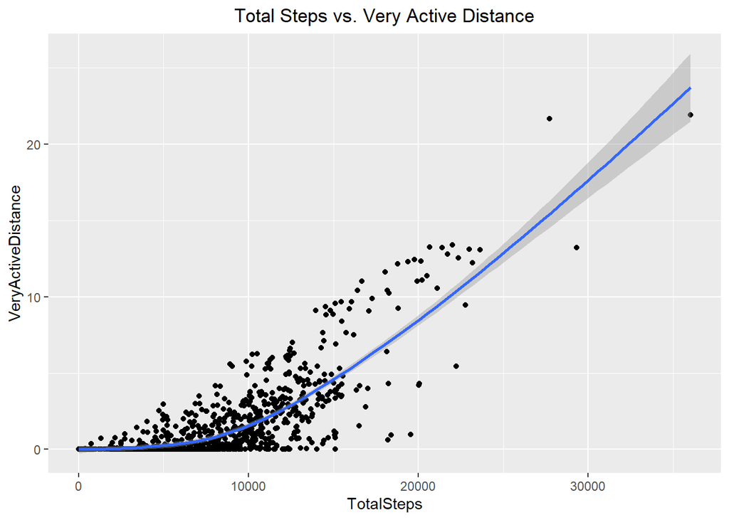

```r
ggplot(data=daily_activity, aes(x=TotalSteps, y=VeryActiveDistance)) +
  geom_point() + geom_smooth() +
  labs(title = "Total Steps vs. Very Active Distance")+
  theme(plot.title = element_text(hjust = 0.5))
```

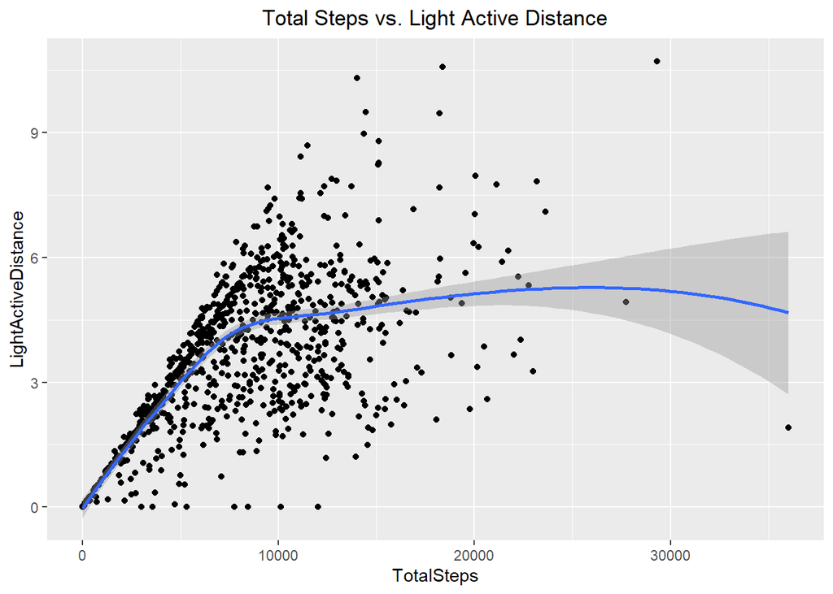

```r
ggplot(data=daily_activity, aes(x=TotalSteps, y=LightActiveDistance)) +
  geom_point() + geom_smooth() +
  labs(title = "Total Steps vs. Light Active Distance")+
  theme(plot.title = element_text(hjust = 0.5))
```

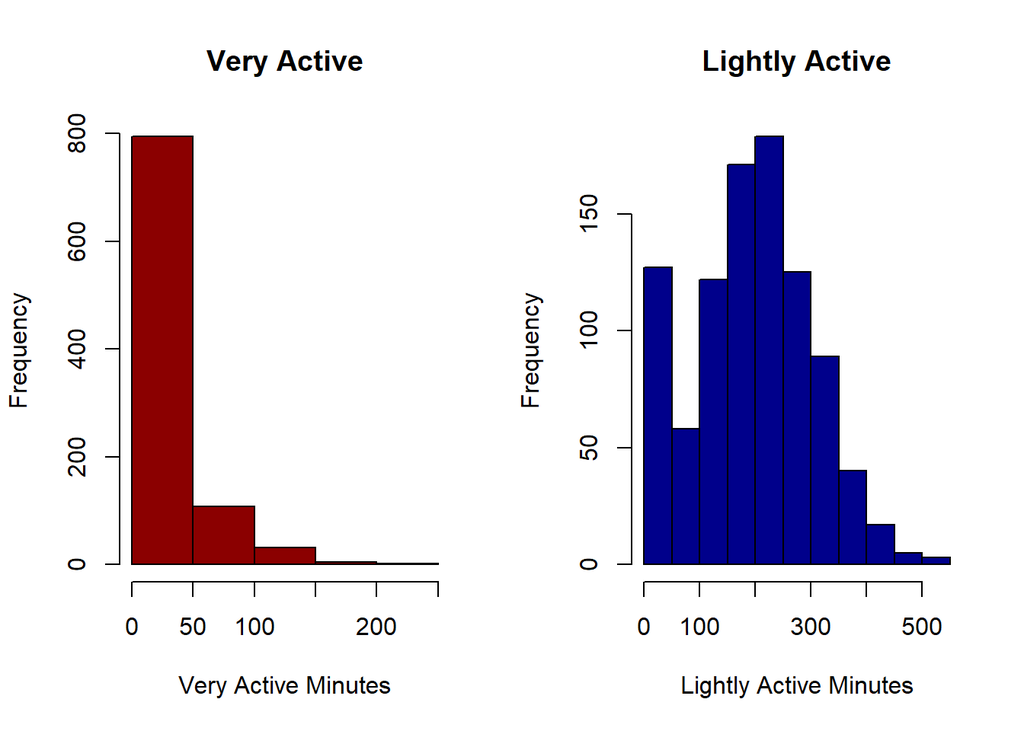

```r
par(mfrow=c(1,2))
hist(daily_activity$VeryActiveMinutes, co = "darkred", main = "Very Active", xlab = "Very Active Minutes", breaks = 7)
hist(daily_activity$LightlyActiveMinutes, co ="darkblue", main = "Lightly Active", xlab = "Lightly Active Minutes", breaks = 10)
```

The blue ‘Lightly Active Minutes’ graph has more instances with intervals between 0 and 50, 50 and 100. The most significant frequency of lightly active minutes recorded was in the 200 and 250 range or time intervals with a longer tail to the right than to the left. There is also a minor hill whose peak is at the 0-50 minute range.

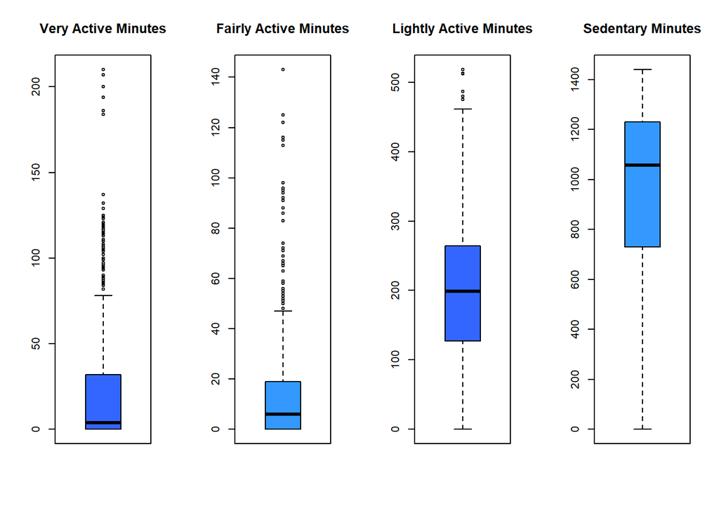

```r
par(mfrow=c(1,4))

boxplot(daily_activity$VeryActiveMinutes, main = "Very Active Minutes", col="#3366FF")

boxplot(daily_activity$FairlyActiveMinutes, main = "Fairly Active Minutes", col = "#3399FF")

boxplot(daily_activity$LightlyActiveMinutes, main = "Lightly Active Minutes", col ="#3366FF")

boxplot(daily_activity$SedentaryMinutes, main = "Sedentary Minutes", col ="#3399FF")
```